# Introduction

### Correlation Between GDP and Life Expectancy of All Six Countries

```python
# Calculate the correlation coefficient
correlation_coefficient = df['GDP'].corr(df['LEABY'])
print(f"Correlation Coefficient between GDP and Life Expectancy: {correlation_coefficient}")
```

```
Correlation Coefficient between GDP and Life Expectancy: 0.3432067484491559
```

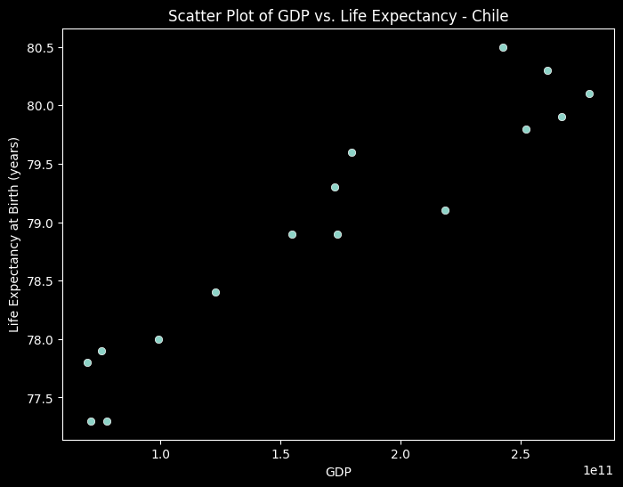

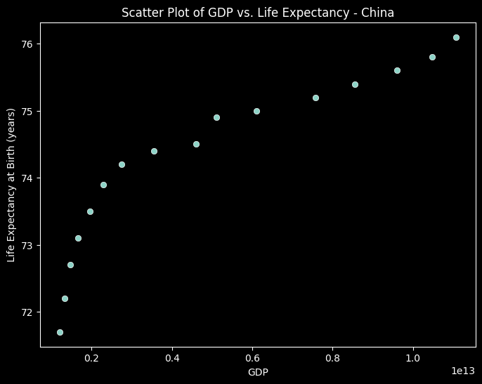

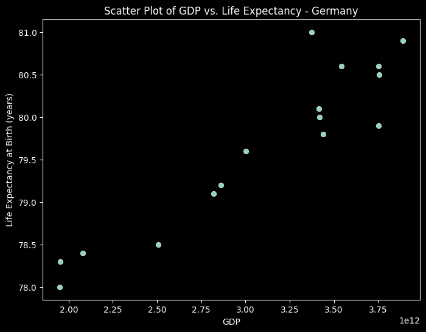

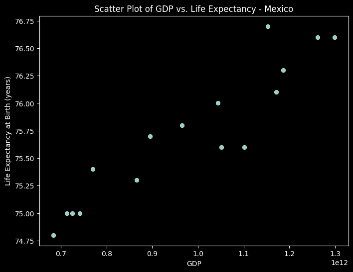

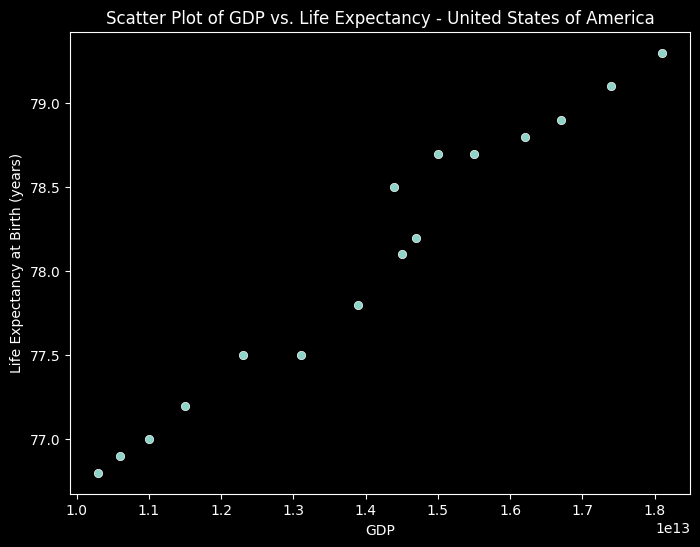

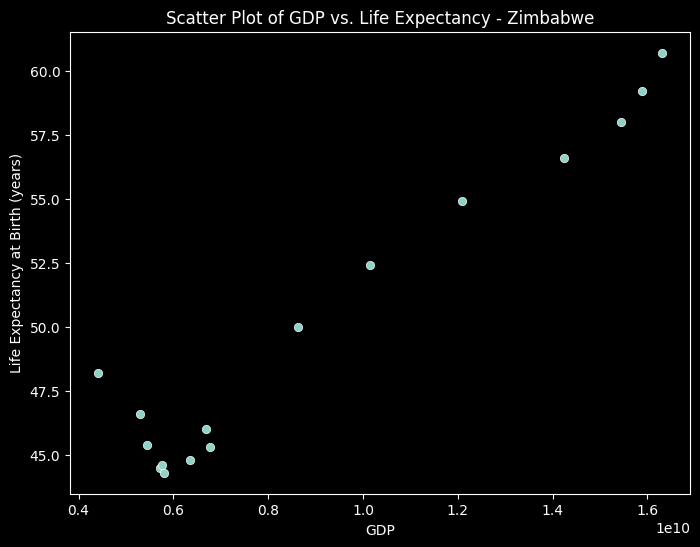

```python
# Get unique country names
unique_countries = df['Country'].unique()

# Create a scatter plot for each country
for country in unique_countries:
    # Filter data for the current country
    country_data = df[df['Country'] == country]

    # Create a scatter plot
    plt.figure(figsize=(8, 6))
    sns.scatterplot(data=country_data, x='GDP', y='LEABY')

    # Customize plot labels and title
    plt.xlabel('GDP')
    plt.ylabel('Life Expectancy at Birth (years)')
    plt.title(f'Scatter Plot of GDP vs. Life Expectancy - {country}')

    # Show the plot for the current country
    plt.show()
```

The correlation coefficient between GDP and life expectancy for the analyzed data is approximately 0.3432. This positive correlation coefficient indicates a positive linear relationship between a country's GDP and its life expectancy at birth (LEABY). In other words, as a country's GDP increases, its life expectancy tends to increase as well.

However, it's important to note that correlation does not imply causation. While there is a correlation between GDP and life expectancy, various other factors may also influence life expectancy, and this correlation does not necessarily indicate a direct causal relationship.

This information can be valuable for understanding the general trends in the dataset and exploring potential associations between economic prosperity (GDP) and public health (life expectancy) across different countries.